# The Cost of Voting Index

Fifty-six election laws compressed into one number, and the decisions that decide what it says

Democracy’s Data

Last updated September 13, 2026 at 10:53a EDT

A voter in Oregon is mailed a ballot. It arrives unasked for, it carries prepaid postage, and it can go in a drop box or in the mail. Nobody checks identification, because nobody meets the voter.

A voter in Mississippi is not mailed a ballot. Voting absentee there means qualifying under a fixed list of excuses, requesting the ballot, enclosing a copy of an identification document, and getting the envelope notarized. Voting in person means producing a photo ID, having registered thirty days earlier.

Those are two different acts wearing the same name. Is it genuinely harder to vote in some states than in others, and how would you measure that? Both voters are casting the same federal vote, and the difference between them is written entirely in state law.

## The test

Somebody has already tried to measure it. The Cost of Voting Index reads the election law of all fifty states, scores it against a fixed list of considerations, and compresses the result into one value per state per election: an **index**, many rules folded into one number. It was built by the political scientists Quan Li, Michael Pomante and Scot Schraufnagel, who published it in 2018 with scores for every presidential election back to 1996,[^1] and Pomante has since extended it through 2024.[^2] The scores, the laws behind them and the codebook are published by the authors at https://costofvotingindex.com.

This brief joins three sources on one key: the state, in an election year. The index supplies the laws and the score. Turnout comes from the United States Elections Project’s turnout tables, maintained by the political scientist Michael McDonald at the University of Florida and downloadable at https://election.lab.ufl.edu/data-downloads/, measured over the voting-eligible population, meaning adult citizens less those a state’s felony law excludes. Party control of state government is not in the index at all. For 1996 through 2008 it is the political scientist Carl Klarner’s state partisan balance measures, as carried in Michigan State University’s Correlates of State Policy collection, downloadable at https://ippsr.msu.edu/public-policy/correlates-state-policy; later elections are coded from governors and chamber majorities. A *trifecta*, below, is one party holding the governorship and both chambers of the legislature.

This index can answer the question, where most cannot, because it publishes its own ingredients. The laws, the codebook and the component weights are all on the site, so the number can be rebuilt rather than taken on trust. Every join here inherits the assumptions of both files, plus one more about how they line up. Join Keys and Crosswalks is the chapter on that third assumption, and on the crosswalk, a table that translates one set of identifiers into another.

## The data

450 rows: fifty states, 9 elections. Each row carries the state’s `final` score, its `final_rank`, and the ten *issue areas* the score is built from. `covi_2024.csv` holds one election with `vep_turnout` and `control` joined on; `covi_panel.csv` holds them all.

| State | Reg. deadline | Voter ID | Early voting | Absentee | Inconveniences | COVI | Rank |
| --- | --- | --- | --- | --- | --- | --- | --- |
| Oregon | 21 | 0 | 0 | 0 | 2 | -2.314250 | 2 |
| Pennsylvania | 15 | 0 | 42 | 3 | 9 | 0.399019 | 26 |
| Mississippi | 30 | 4 | 42 | 8 | 10 | 2.010490 | 50 |

Each of those columns is a different kind of thing, which is the first thing to notice about the file. **`reg. deadline` and `early voting` are numbers of days.** **`voter ID` is a five-point scale**, from no identification required to strict photo. **`absentee` and `inconveniences` are counts of restrictions**, each one a law that either exists in a state or does not. Everything is oriented so that bigger is worse. Underneath the ten columns sit 52 individual yes-or-no items, listed in `items_2024.csv`, and the additive issue areas are those items added up.

The recipe for turning them into one number is published. Standardize the ten issue areas, which means putting each on the same scale by subtracting its fifty-state average and dividing by its spread, so that a column measured in days and a column measured on a five-point scale count alike. Run a principal component analysis, which takes ten correlated columns and finds the directions along which states differ most, and keep the first four of those directions, the components. Then add them up, weighting each by how much of the variation it accounts for, which means counting some parts of the score for more than others.

Standardizing is the step to hold onto. Take Mississippi, the hardest state in the file. Its registration deadline is 30 days before the election, against a fifty-state average of 13.1 days with a spread, a standard deviation, of 13.1; subtract the average and divide by the spread and the deadline becomes 1.29, about one spread above the average state. Its voter-identification score is 4 on the five-point scale, against an average of 1.68 and a spread of 1.45, so standardized it is 1.60. On their own scales a 30 dwarfs a 4; standardized, both say the same kind of thing, how unusual the state is, in the same units. The principal component analysis then combines the ten standardized columns into four weighted sums, adds those, and for Mississippi the arithmetic gives 2.01, the highest score of the fifty.

| Check | Result |
| --- | --- |
| States rebuilt from the published laws | 50 |
| Largest difference from the published score | 0.000265 |
| States landing in the same rank | 50 of 50 |
| Correlation with the published index | 1.000000 |

**The index rebuilds exactly** from the published laws. Every state lands in the same rank, and the largest disagreement is 0.000265 on a scale running from about −2.5 to 2. That matters below, because when this brief re-weights the index it re-weights the real thing rather than a model of it.

> **Before you read on, commit to a number.** The index weights its four components by variance. Suppose you weighted them equally instead, a rule at least as easy to defend. **How many places would the worst-affected state move?** Write down a number out of 50.

## What it says about democracy

The states really are far apart. Washington scores -2.48 and Mississippi scores 2.01, and the spread between them is the largest thing in the file.

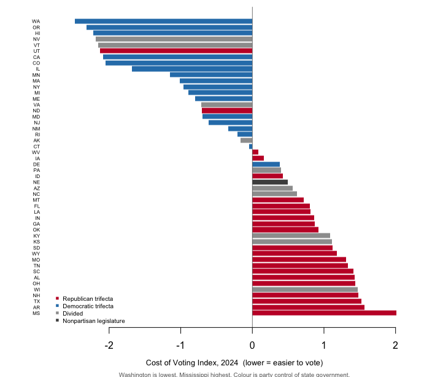

Cost of Voting Index, 2024 (lower = easier to vote). Hover a bar for the state, its rank and its turnout.

**Figure 1. The 2024 Cost of Voting Index, all fifty states.** Lower is easier. A sorted bar per state is the right form because the data is fifty named cases with one value each, and the question is who sits where in the order. The colour is party control, joined on from outside; the index does not contain it.

Now the answer to the prediction. Equal weights move the average state 5.2 places and the worst-affected state 16. Leaving the ten issue areas unstandardized moves one state 28 places.

| Weighting rule | What changes | Mean rank move | Biggest move |
| --- | --- | --- | --- |
| Published index | – | – | – |
| Four components weighted equally | variance weights dropped | 5.2 | 16 (Delaware) |
| First component alone | the other three components dropped | 2.9 | 15 (Wisconsin) |
| Issue areas not standardized | days and points left on their own scales | 7.9 | 28 (Rhode Island) |

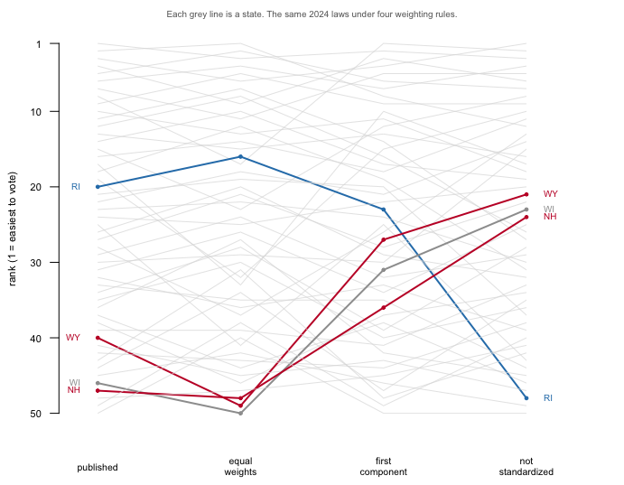

**Figure 2. The same fifty states, ranked four ways.** Each line is a state, carried from its published rank across three alternative weighting rules. No law changed between the columns.

The published rule is not wrong. The point is that the rule is a choice, the choice is invisible in the number, and a state’s rank is partly an artifact of it. Rhode Island ranks 20 of 50 under the published rule and 48 unstandardized. A reader given either number has been told something about Rhode Island’s laws and something about a decision made in a spreadsheet, in unmarked proportions.

Variance weighting has one further consequence that is easy to state and hard to unsee. *A law that nearly every state has cannot matter much, no matter how burdensome it is.*

| Law item | States scoring it | Standard deviation |
| --- | --- | --- |
| NoFelonsReg | 48 | 0.20 |
| noallmailornopolllocations | 43 | 0.35 |
| noallmailvoting | 42 | 0.37 |
| NoPostcardAutoreg | 40 | 0.40 |
| NoDriveAllowed | 3 | 0.24 |
| PR17 | 3 | 0.24 |
| ReducePollingLoc>50%someareas | 3 | 0.24 |
| nofoodordrink | 3 | 0.24 |
| strictID | 3 | 0.24 |
| PR90 | 1 | 0.14 |
| PR60 | 1 | 0.14 |
| restrictdistofabsenteeballotscounty | 1 | 0.14 |

**48 of 50 states forbid people in prison from registering to vote.** As a barrier that is absolute. It is the difference between voting and not voting for everyone it touches: the Sentencing Project’s count puts roughly four million American adult citizens barred from voting over a felony conviction, about three in ten of them in prison or jail.[^3] As a *variable* it is nearly worthless, because it barely separates one state from another, and it sits in the index carrying a standard deviation of 0.20. That is what an index buys and what it hides: a single comparable number, at the price of everything the states agree about.

That leads directly to the assumption the whole enterprise rests on, which is that cost affects behaviour.

| State | Cost rank | COVI | Turnout |
| --- | --- | --- | --- |
| Oregon | 2 | -2.31 | 71.9% |
| Hawaii | 3 | -2.22 | 50.3% |
| Wisconsin | 46 | 1.47 | 76.7% |
| Texas | 48 | 1.52 | 56.8% |
| Mississippi | 50 | 2.01 | 57.8% |

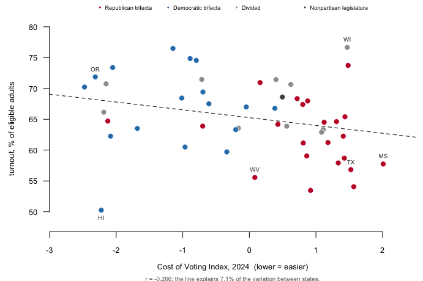

**Figure 3. Cost against turnout, 2024.** Each point is a state, and the dashed line is the best straight line through them. It slopes the way the theory says it should, with a correlation of -0.266 on a scale where −1 would mean cost predicts turnout perfectly and 0 not at all, and explains 7.1% of the variation between states.

Hawaii is the 3rd easiest state in which to vote and turns out 50.3% of its eligible adults. Mississippi is the hardest of all 50 and turns out 57.8%, which is 7.5 points *higher*. Wisconsin ranks 46th on cost and turns out 76.7%.

Three readings of that scatter are available. Cost may genuinely matter little at the margins the states actually occupy. The index may be measuring the wrong thing, scoring statutes rather than the experience of voting. Or turnout may be driven by something stronger and absent here, such as how competitive the state is. What the figure establishes is narrower and worth having: whatever drives American turnout, it is not mostly the ease of voting.

One pattern the index carries easily, and it is the largest in the data.

| Year | R trifecta | D trifecta | Divided | R minus D | Control from |
| --- | --- | --- | --- | --- | --- |
| 1996 | 18.5 | 29.5 | 28.9 | -11.0 | Klarner |
| 2000 | 21.7 | 31.2 | 26.0 | -9.5 | Klarner |
| 2004 | 27.9 | 25.1 | 24.7 | 2.8 | Klarner |
| 2008 | 25.2 | 20.7 | 28.7 | 4.5 | Klarner |
| 2012 | 31.7 | 19.6 | 20.9 | 12.0 | coded here |
| 2016 | 33.4 | 13.6 | 21.6 | 19.8 | coded here |
| 2020 | 34.1 | 13.1 | 26.4 | 21.0 | coded here |
| 2022 | 34.8 | 11.8 | 24.5 | 23.0 | coded here |
| 2024 | 35.7 | 12.4 | 25.1 | 23.3 | coded here |

In 1996 the average Republican-trifecta state ranked 18.5 of 50 and the average Democratic-trifecta state ranked 29.5. Voting was easier, on average, in the states Republicans controlled. The lines cross in 2004, and by 2024 the gap has inverted and widened to 23.3 places the other way.

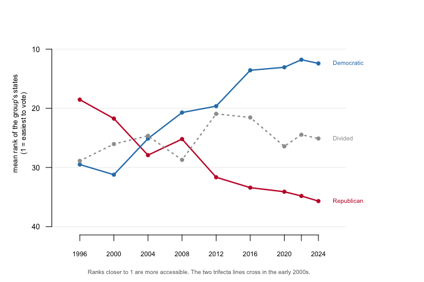

## What this brief cannot tell you

**It measures statutes, not experience.** Every quantity in it is a property of a state’s law, so two counties in the same state have the same score. A five-hour line in one and a five-minute line in the next are the same observation. Where election administration actually varies, county by county, this index is silent by design.

**Its weights come from variance, not from burden.** It would not notice if all fifty states adopted the same harsh new requirement tomorrow, because nothing would have changed *between* states. An index that cannot detect a nationwide restriction is measuring dispersion rather than cost.

**Its nine years are not one instrument.** The index was built from 6 issue areas in 1996 and 10 in 2024, and the components are re-estimated on each year’s set. The back series has also been rewritten: the 1996 index as first published and as the current file gives it correlate 0.597, with the average state moving 13.6 places and Tennessee moving 40.

**Its yes-or-no items flatten laws that are not yes-or-no.** Which photo IDs count, and how long a voter has to cure a provisional ballot, differ by state and decide who actually votes.

**And it has no people in it.** No race, no age, no income. The claim that most motivates this literature is that voting costs fall hardest on people with the least slack in their lives, and this file cannot test it.

## What you should have learned

- American states impose genuinely different costs to cast the same federal vote: Washington scores -2.48 and Mississippi scores 2.01 on the 2024 index.
- An index is a weighting rule wearing a number’s clothing. Weighting the four components equally moves the average state 5.2 places and one state 16; leaving the issue areas unstandardized moves one state 28.
- Variance weighting measures how unusual a state is, not how hard it is to vote there. The item 48 of 50 states share carries a standard deviation of 0.20 and is nearly invisible in the score.
- Cost explains 7.1% of the variation in 2024 turnout between states, and Mississippi, the hardest state of all, turns out 7.5 points above the 3rd easiest.
- The parties swapped ends. The average Republican-trifecta state ranked 18.5 of 50 in 1996 against 29.5 for Democratic trifectas, and 35.7 against 12.4 in 2024.

## Extensions

None of these is answered above, and every one can be answered from the tables the Sources section hands over.

- `reweight_2024.csv` re-ranks every state three other ways in `equal_rank`, `pc1_rank` and `unstandardized_rank`. Sort by `unstandardized_move` and read the ten biggest movers. Do they have anything in common?
- `covi_2024.csv` puts `vep_turnout` next to `final_rank` and `control`. Group the states by `control` and compare each group’s average turnout against its average cost rank.
- `items_2024.csv` has `states_scored` and `sd` for every law item. Sort by `states_scored` and list the ten laws nearly every state has. Which would you call the heaviest burden?
- `covi_panel.csv` carries `initial` and `final` for every state in every year. Pick a state and follow both columns across nine elections. Does its score move when its party control changes, or before?
- **Stretch.** Check three states’ current law on one issue area against a state legislature’s own website. How many still match what the index says?
- **Stretch.** Find a county-level source for wait times or polling-place closures in one state. Is the variation inside that state larger than the variation between states this index measures?

## Sources

**Data**

- Michael J. Pomante II, *Cost of Voting Index*, https://costofvotingindex.com — the Data page, which publishes the COVI values and ranks for 1996 through 2024, the master spreadsheet of state voting requirements, and the codebook defining every item. All three are kept as they were downloaded in August 2026, because the announced 2026 edition will re-estimate the whole series.
- Turnout is the 2024 rate over the voting-eligible population, from the United States Elections Project’s general election turnout series (Michael McDonald, University of Florida), https://election.lab.ufl.edu/data-downloads/. That file was still a preliminary release when it was taken.
- Party control of state government came from two places. For 1996 through 2008 it is Carl Klarner’s state partisan balance measures, in the Correlates of State Policy Project (Grossmann, Jordan and McCrain, Michigan State University), https://ippsr.msu.edu/public-policy/correlates-state-policy. The 2012 through 2024 elections were classified from each state’s governor and chamber majorities and tested against Pomante (2025) Table 2; the Klarner years differ from that test on 3 states.

**The data itself**

Every figure above is drawn from these tables. They are plain CSV, they open in a spreadsheet, and they are yours to take further.

`control_check.csv`, `control_panel.csv`, `control_trend.csv`, `covi_2024.csv`, `covi_panel.csv`, `items_2024.csv`, `rebuild_2024.csv`, `reweight_2024.csv`, `year_structure.csv`

Two more files here are not data about the subject at all – they are how this chapter checked its own work: `facts.csv`, the individual numbers the text above quotes, and `checks.csv`, the arithmetic verified before anything was drawn.

**Academic literature**

- Pomante, M. J. II (2025). “Cost of Voting in the American States: 2024.” *Election Law Journal* 24(1): 52–61. doi:10.1089/elj.2024.0037; the index’s own site links the article from https://costofvotingindex.com/publications.
- Li, Q., Pomante, M. J. II and Schraufnagel, S. (2018). “Cost of Voting in the American States.” *Election Law Journal* 17(3): 234–247. The paper that built the 1996–2016 series. doi:10.1089/elj.2017.0478.
- Klarner, C. (2013). “State Partisan Balance Data, 1937–2011.” Harvard Dataverse, hdl:1902.1/20403.
- Uggen, C., Larson, R., Shannon, S. and Stewart, R. (2024). *Locked Out 2024: Four Million Denied Voting Rights Due to a Felony Conviction.* The Sentencing Project — the four million figure quoted above. https://www.sentencingproject.org/reports/locked-out-2024-four-million-denied-voting-rights-due-to-a-felony-conviction/

Why this data cannot be fetched again

[output not shown]

[^1]: Quan Li, Michael J. Pomante II and Scot Schraufnagel, “Cost of Voting in the American States,” *Election Law Journal* 17, no. 3 (2018): 234–247, doi:10.1089/elj.2017.0478.
[^2]: Michael J. Pomante II, “Cost of Voting in the American States: 2024,” *Election Law Journal* 24, no. 1 (2025): 52–61, doi:10.1089/elj.2024.0037.
[^3]: Christopher Uggen, Ryan Larson, Sarah Shannon and Robert Stewart, *Locked Out 2024: Four Million Denied Voting Rights Due to a Felony Conviction* (Washington: The Sentencing Project, 2024), https://www.sentencingproject.org/reports/locked-out-2024-four-million-denied-voting-rights-due-to-a-felony-conviction/.